# K_means_clustering_algorithm

#### Synthetic data - K-Means

```python
k = 2

clusters1 = main(X_test1_array, k, euclidean_distance, threshold = 1/10)
```

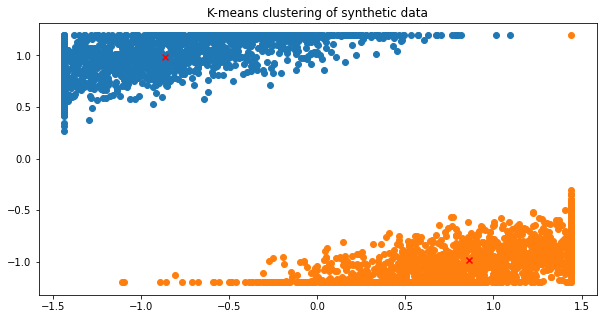

```python
import matplotlib.pyplot as plt

plt.rcParams['figure.figsize'] = [10, 5]
for centroid, values in clusters1.items():
    values = np.array(values)
    centroid = np.mean(values, axis=0)
    plt.scatter(values[:, 0], values[:, 1], marker='o')
    plt.grid()
    plt.scatter(centroid[0], centroid[1], marker='x', color="red")
    plt.title("K-means clustering of synthetic data")

plt.show()
```

#### Spam email data - K-Means

```python
k = 2

clusters2 = main(X_test2_array, k, euclidean_distance, threshold = 1/10)
```

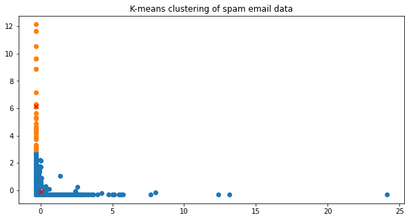

```python
import matplotlib.pyplot as plt

plt.rcParams['figure.figsize'] = [10, 5]

for centroid, values in clusters2.items():
    values = np.array(values)
    centroid = np.mean(values, axis=0)
    plt.scatter(values[:, 0], values[:, 1], marker='o')
    plt.grid()
    plt.scatter(centroid[0], centroid[1], marker='x', color="red")
    plt.title("K-means clustering of spam email data")

plt.show()
```

This chart is deceiptive since the data is in 5D.

### 7. Model assessemnt - Silhouette Coefficient

```python
def intra_cluster_distance(X1, X2):
    """
    Calculate the distance between a point and every other point in a class
    Determine the class with most data to use
    """
    N1 = X1.shape[0]
    N2 = X2.shape[0]
    distance = []
    if N1>=N2:
        for i in range(N1):
            for j in range(N1):
                distance.append(sum((X1[i, :]-X1[j, :])**2))
    else:
        for i in range(N2):
            for j in range(N2):
                distance.append(sum((X2[i, :]-X2[j, :])**2))

    return np.array(distance)

def inter_cluster_distance(X1, X2):
    """
    Calculate the distance between a point and points in the other class
    """
    N1 = X1.shape[0]
    N2 = X2.shape[0]
    distance = []
    if N1>=N2:
        for i in range(N2):
            for j in range(N1):
                distance.append(sum((X2[i,:]-X1[j,:])**2))
    else:
        for i in range(N1):
            for j in range(N2):
                distance.append(sum((X1[i,:]-X2[j,:])**2))
    return np.array(distance)

def silhouette_coefficient(X_class0, X_class1):

    a = intra_cluster_distance(X_class0, X_class1)

    b = inter_cluster_distance(X_class0, X_class1)

    silhouette = [(i-j)/max(i,j) for i,j in zip(b, a)]

    return silhouette

def average_silhouette(silhouette):

    return float(sum(silhouette)/len(silhouette))
```

#### Synthetic data - Silhouette coefficient for K-means

```python
X1 = np.array(clusters1[0])
X2 = np.array(clusters1[1])

silhouette1 = silhouette_coefficient(X1, X2) #Silhouette

average_silhouette1 = average_silhouette(silhouette1) #average Silhouette

print(average_silhouette1)
```

```
0.9086495464572375
```

From the K-means cluster plot, we should expect average Silhouette coefficient of 1. But i got 0.91 this is comparable to the accuracy of 1 in Naive Bayes. However, the fact that we did not get Silhouette coefficient of 1 means there is some misclassification in the data, this is not true per the cluster plot.

#### Spam email data - Silhouette coefficient for K-means

```python
X1 = np.array(clusters2[0])
X2 = np.array(clusters2[1])

silhouette2 = silhouette_coefficient(X1, X2) #Silhouette

average_silhouette2 = average_silhouette(silhouette2) #average Silhouette

print(average_silhouette2)
```

```
0.7814339775412636
```

With the spam email data, the average Silhouette coefficient is 0.78, which is less than the 0.896 classification accuracy obtained with the Naive Bayes classification.